# Análise de Dados

Antonio Eduardo Chaves de Medeiros

8 de julho de 2016

## Dados

Os dados que iremos analizar são relativos aos gastos dos parlamentares registrados na Câmara dos deputados.

```
##    sgPartido         numMes        txtCNPJCPF           vlrGlosa
##  PT     :20143   Min.   :1.000   Min.   :9.415e+06   Min.   :    0.000
##  PMDB   :18534   1st Qu.:2.000   1st Qu.:2.558e+12   1st Qu.:    0.000
##  PSDB   :15702   Median :3.000   Median :7.576e+12   Median :    0.000
##  PP     :13647   Mean   :3.297   Mean   :1.407e+13   Mean   :    2.823
##  PR     :11447   3rd Qu.:4.000   3rd Qu.:1.514e+13   3rd Qu.:    0.000
##  (Other):69614   Max.   :7.000   Max.   :9.859e+13   Max.   :10800.000
##  NA's   :  398                   NA's   :20517
##            txNomeParlamentar       sgUF       nuCarteiraParlamentar
##  DIEGO GARCIA       :  1211   SP     :25165   Min.   :  1.0
##  MIGUEL LOMBARDI    :  1157   MG     :18756   1st Qu.:183.0
##  ANA PERUGINI       :   919   RS     :12975   Median :313.0
##  AFONSO MOTTA       :   858   RJ     :11891   Mean   :303.9
##  JORGE TADEU MUDALEN:   831   PR     :11559   3rd Qu.:445.0
##  LEANDRE            :   816   (Other):68741   Max.   :581.0
##  (Other)            :143693   NA's   :  398   NA's   :398
##   vlrDocumento       nuDeputadoId    numSubCota
##  Min.   :-2911.49   Min.   :  19   Min.   :  1.0
##  1st Qu.:   48.94   1st Qu.:1758   1st Qu.:  3.0
##  Median :  141.35   Median :2340   Median : 11.0
##  Mean   :  599.10   Mean   :2239   Mean   :252.9
##  3rd Qu.:  431.00   3rd Qu.:2961   3rd Qu.:122.0
##  Max.   :97200.00   Max.   :3152   Max.   :999.0
##
##  txtDescricaoEspecificacao  datEmissao        codLegislatura
##  Length:149485             Length:149485      Min.   :54
##  Class :character          Class :character   1st Qu.:55
##  Mode  :character          Mode  :character   Median :55
##                                               Mean   :55
##                                               3rd Qu.:55
##                                               Max.   :55
##                                               NA's   :398
##    numParcela        txtDescricao        txtNumero
##  Min.   :0.0000000   Length:149485      Length:149485
##  1st Qu.:0.0000000   Class :character   Class :character
##  Median :0.0000000   Mode  :character   Mode  :character
##  Mean   :0.0001472
##  3rd Qu.:0.0000000
##  Max.   :1.0000000
##
```

[output cut: 17 more lines]

```
##  Min.   :5865839   Min.   :  4930   Min.   :   0   Length:149485
##  1st Qu.:5931576   1st Qu.: 76287   1st Qu.:2015   Class :character
##  Median :5965899   Median :160565   Median :2015   Mode  :character
##  Mean   :5965359   Mean   :140661   Mean   :2010
##  3rd Qu.:5999538   3rd Qu.:178876   3rd Qu.:2015
##  Max.   :6036549   Max.   :194592   Max.   :2015
##  NA's   :55540     NA's   :398
##   txtTrecho         vlrRestituicao
##  Length:149485      Min.   :  12.00
##  Class :character   1st Qu.:  83.89
##  Mode  :character   Median : 111.94
##                     Mean   : 570.20
##                     3rd Qu.: 991.92
##                     Max.   :2113.55
##                     NA's   :149473
```

## Numero de parlamentares por partido

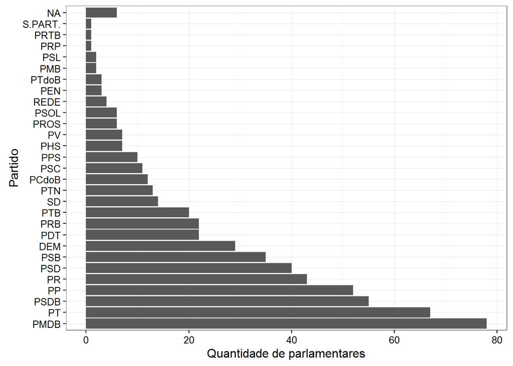

PT e PMDB demostram o porque de serem dois dos mais importantes partidos politicos no Brasil, apresentando quantidade de parlamentares muito superiores à maioria dos outros partidos brasileiros.

## Gastos por partido

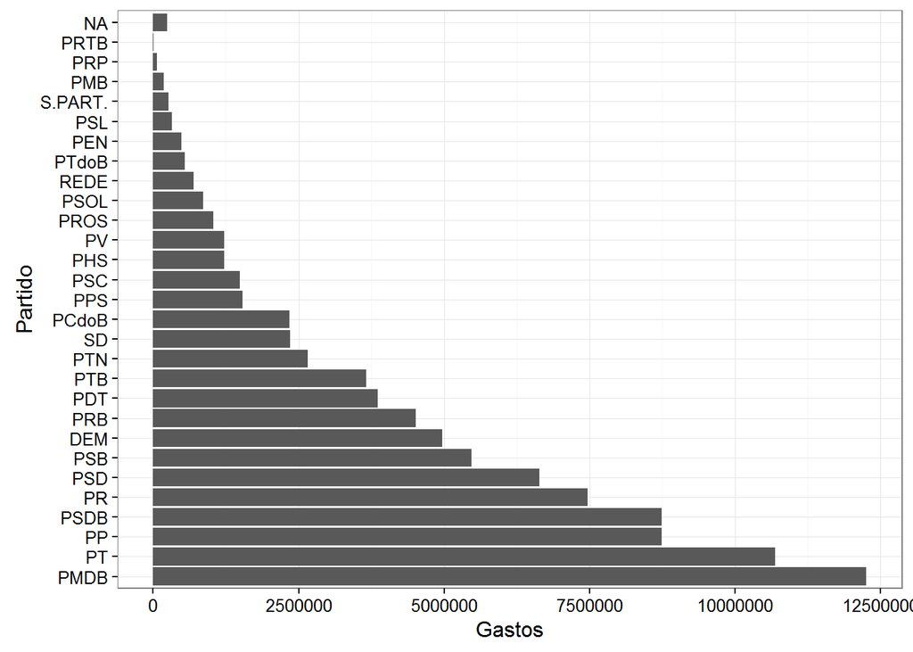

PT e PMDM tambem aparecem na liderança no que se diz respeito aos gastos de seus parlamentares, a relação entre o tamanho do partido e a quantidade de gastos de seus deputados parece apresentar linearidade.

## Total gasto em cada categoria

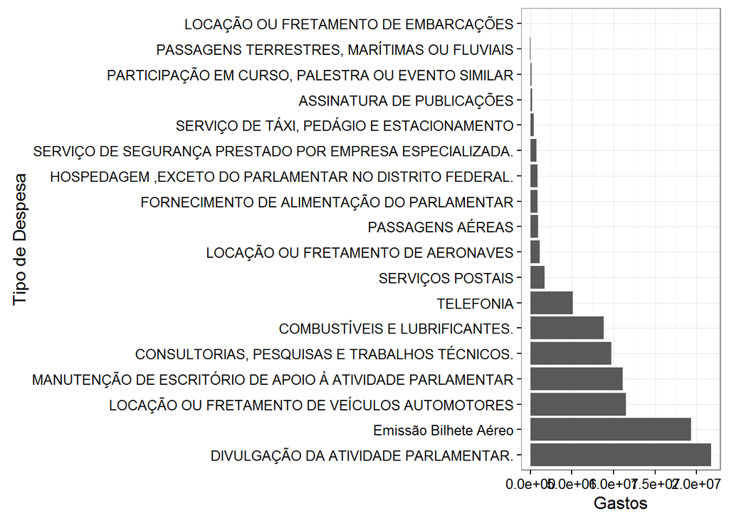

Emissão de Bilhetes Aéreos e Divulgação da Atividade Parlamentar apresentam-se como as maiores despesas parlamentares, se mostrando como quase o dobro de quase todos os outros grandes gastos dos deputados.

## Variação dos gastos em cada categoria

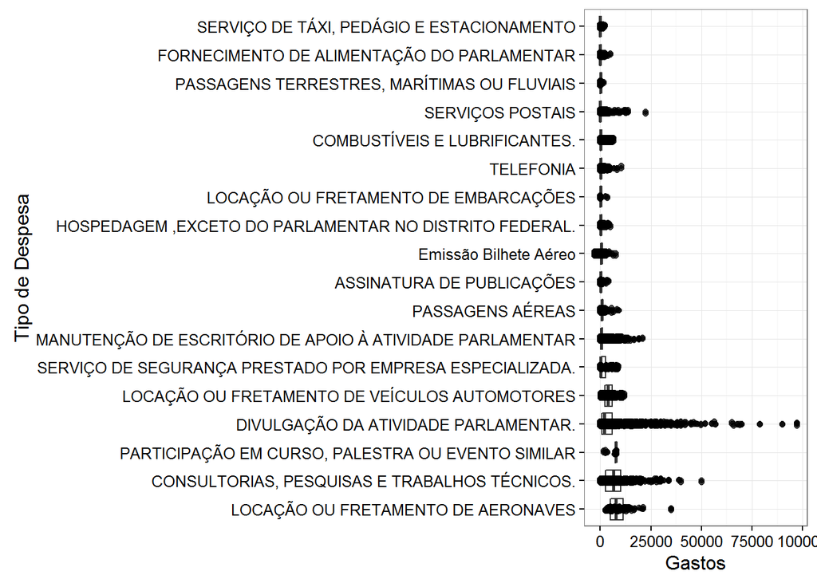

No gráficos podemos perceber que os gastos costumam ser de valores relativamente pequenos, se situando mais na casa de 0 aos 50000 reais, podemos perceber valores extremos como no caso de Emissões de passagens aéreas com valores negativos (Bilhetes de compensação, compensando outro bilhete emitido e não utilizado), e valores muito altos e discrepantes como no caso de alguns gastos com divulgação.

Podemos perceber ainda que a categoria “DIVULGAÇÃO DA ATIVIDADE PARLAMENTAR” possui a maior variação de valores, variando de pequenos gastos, até despesas de dezenas de milhares de reais. O que pode a levantar o questionamento:

## Quais parlamentares tiveram tanta despesa com divulgação?

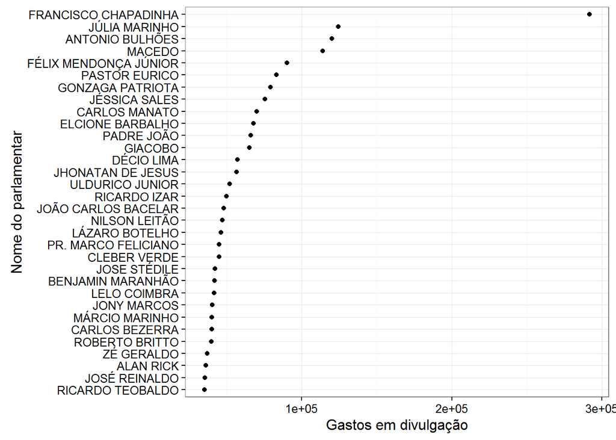

Podemos ver que “Francisco Chapadinha” divulga bastante as atividades parlamentares, embora seja um parlamentar do qual nunca ouvi falar, muito menos das atividades que realiza.

## Deputados que mais gastam

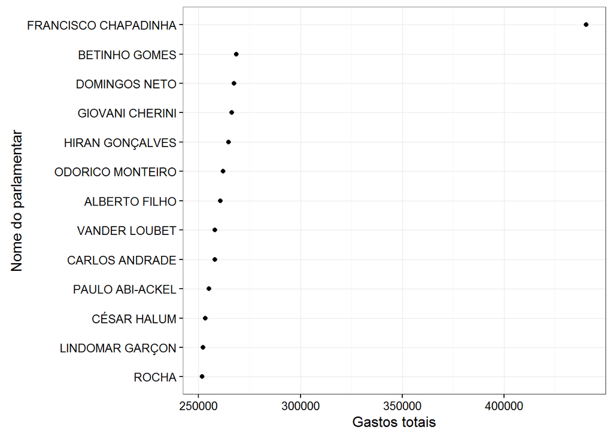

Novamente, “Francisco Chapadinha” aparece como o parlamentar que mais gastou verba pública, com valores bem superiores se comparado com os outros. O mais interessante é que, embora o PT e PMDB sejam as maiores bancandas no parlamento, “Francisco Chapadinha” é parlamentar do PTN do Pará, comparando com a tabela de gastos por partido, podemos perceber que “Francisco Chapadinha” é responsável por boa parte dos gastos de seu partido inteiro.